# Progress Memo 1

Final Project  
Data Science 2 with R (STAT 301-2)

Author

Brian Dinh

Published

February 2, 2024

**Github Repo Link**

[This is the link to the GitHub Repository.](https://github.com/stat301-2-2024-winter/final-project-2-BrianDinh26.git)

## Data source

My data source is a used cars dataset from Kirill Lepchenkov on Kaggle.[^1]

<sup>1</sup> [Used Cars Dataset on Kaggle.](https://www.kaggle.com/datasets/lepchenkov/usedcarscatalog/data)

## Why this data and prediction problem

My prediction objective is to predict the price of cars using data related to used cars online. This will be a regression problem. Having a model would be useful for this objective because it can help potential car buyers assess if they might be overpaying for a used car. Additionally, I am interested in the used car market because I am trying to buy my first car in the summer through the used car market.

## Data quality & complexity check

```r
# data read-in
cars <- read_csv(here("data/cars.csv"))

head(cars, n = 5) |>
  DT::datatable()
```

|  | manufacturer_name | model_name | transmission | color | odometer_value | year_produced | engine_fuel | engine_has_gas | engine_type | engine_capacity | body_type | has_warranty | state | drivetrain | price_usd | is_exchangeable | location_region | number_of_photos | up_counter | feature_0 | feature_1 | feature_2 | feature_3 | feature_4 | feature_5 | feature_6 | feature_7 | feature_8 | feature_9 | … |
| --- | --- | --- | --- | --- | --- | --- | --- | --- | --- | --- | --- | --- | --- | --- | --- | --- | --- | --- | --- | --- | --- | --- | --- | --- | --- | --- | --- | --- | --- | --- |
| 1 | Subaru | Outback | automatic | silver | 190000 | 2010 | gasoline | False | gasoline | 2.5 | universal | False | owned | all | 10900 | False | Минская обл. | 9 | 13 | False | True | True | True | False | True | False | True | True | True | … |
| 2 | Subaru | Outback | automatic | blue | 290000 | 2002 | gasoline | False | gasoline | 3 | universal | False | owned | all | 5000 | True | Минская обл. | 12 | 54 | False | True | False | False | True | True | False | False | False | True | … |
| 3 | Subaru | Forester | automatic | red | 402000 | 2001 | gasoline | False | gasoline | 2.5 | suv | False | owned | all | 2800 | True | Минская обл. | 4 | 72 | False | True | False | False | False | False | False | False | True | True | … |
| 4 | Subaru | Impreza | mechanical | blue | 10000 | 1999 | gasoline | False | gasoline | 3 | sedan | False | owned | all | 9999 | True | Минская обл. | 9 | 42 | True | False | False | False | False | False | False | False | False | False | … |
| 5 | Subaru | Legacy | automatic | black | 280000 | 2001 | gasoline | False | gasoline | 2.5 | universal | False | owned | all | 2134.11 | True | Гомельская обл. | 14 | 7 | False | True | False | True | True | False | False | False | False | True | … |

### Missingness check

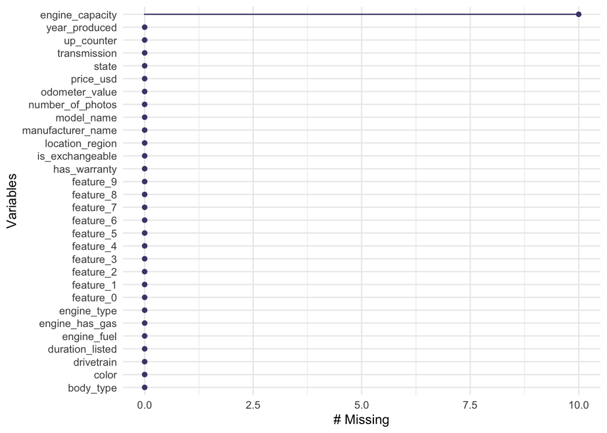

```r
gg_miss_var(cars)
```

## Potential data issues

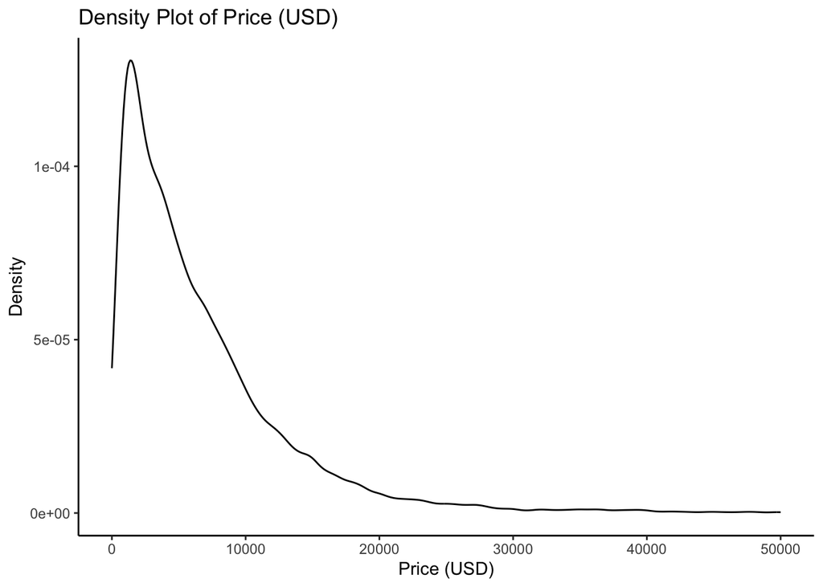

Based on the following density plot, it seems that there is a right skew on car prices. There does not appear to be missingness issues. To deal with the right skew, I can transform the dataset using a log transformation. Additionally, I can remove outliers, because the majority of the prices are from the price range of $0 to $15,000.